# Working with Transactions

Mustafa Ascha

September 11, 2016

In the last post, we went through the process of simulating some random billing claims data, then putting it through the CSPADE algorithm to see if there were any interesting frequent sequences.

Before we begin any coding, I’d like to point out that our model will involve considering patients as transactions, and diseases as items. When a patient has a set of diseases, and two of those diseases also occur in many other patients, we’ll have an association rule with high “support”. For more on understanding association rules, [check out the `arules` package author’s document.](http://michael.hahsler.net/research/arules_RUG_2015/demo/) It’s a great website, and I highly recommend reading through it.

## Load libraries, get data

First, of course, we’ll have to load some libraries:

```r
library(arules)
```

```r
library(arulesViz)
library(dplyr)
library(ggplot2)
```

Here’s how to make the data we’ll use.

Because this is a simulation, there will be some randomness involved. To make sure you can replicate everything, we’ll set a seed:

```r
set.seed(9001)
```

```r
diseases <-
    c("Heart_disease",
      "Hypertension",
      "Kidney_disease",
      "Liver_cirrhosis",
      "Gall_stones",
      "Kidney_stones",
      "Tonsiliths",
      "Unspecified_cancer",
      "Vitamin_D_deficiency",
      "Trichtillomania",
      "Psoriasis",
      "Esophagitis",
      "Otitis_media",
      "Ingrown_toenail",
      "ADHD",
      "Arthritis",
      "Chlamydia",
      "Parasites_Scabies",
      "Meningitis",
      "Zika_Virus",
      "Hepatitis",
      "Giardiasis",
      "Takatsubo_Cardiomyopathy",
      "Flu",
      "Obesity",
      "Latex_allergies",
      "Lice",
      "Legionellosis",
      "Lymphocytic_Choriomeningitis",
      "Tetanus",
      "Ticks_Lyme_Disease",
      "Tuburculosis",
      "Trench_fever",
      "Creutzfeldt-Jakob_Disease",
      "Hearing_loss")

claims_data <-
    data.frame(disease = sample(diseases, 100, replace = TRUE),
           patient = rep_len(1:10, 100), stringsAsFactors = FALSE)
```

## Format data for arules

Given some data, let’s prepare it for associations analysis. We’ll use the `split` command to produce a list of the diseases that contains a vector of patient identifiers for patients with those diseases.

Here we go:

```r
claims_tx <- split(claims_data$patient, claims_data$disease)
```

I’ll be artificially adding “Hypertension” and “Kidney disease” to several of the patients, just to make sure arules works. ;)

```r
claims_tx$Hypertension <- c(claims_tx$Hypertension, 1:3)

claims_tx$Kidney_disease <- c(claims_tx$Kidney_disease, 1:3)
```

Hopefully that will work..

Note that `arules` won’t accept “tidLists” with a transaction listed more than once. In our case, that means that patients who have several of the same diagnosis will be considered only in terms of their yes-no disease status. If you’re interested in recommender systems that can handle ratings or counts data, I recommend looking into [collaborative filtering approaches](https://en.wikipedia.org/wiki/Netflix_Prize).

```r
claims_tx <- lapply(claims_tx, function(x) sort(unique(x)))

claims_tx <- as(claims_tx, "tidLists")
```

## Checking out our data

Even before running the *apriori* or *eclat* algorithms, there’s a lot to learn about the data.

Here’s what R shows when you ask for the object:

```r
claims_tx
```

```
## tidLists in sparse format with
##  35 items/itemsets (rows) and
##  10 transactions (columns)
```

That’s useful–we know how many items (diagnoses) and how many transactions (patients) we have.

We can also `inspect` the claims:

```r
claims_inspect <- inspect(claims_tx)
```

| items | transationIDs |
| --- | --- |
| ADHD | {3,4,10} |
| Arthritis | {6} |
| Chlamydia | {9,10} |
| Creutzfeldt-Jakob_Disease | {2,8} |
| Esophagitis | {1,2,4} |
| Flu | {7,10} |
| Gall_stones | {10} |
| Giardiasis | {3,8,9} |
| Hearing_loss | {9} |
| Heart_disease | {1,9} |
| Hepatitis | {2} |
| Hypertension | {1,2,3,5,8,10} |
| Ingrown_toenail | {5,6} |
| Kidney_disease | {1,2,3,4,5} |
| Kidney_stones | {1,2,9} |
| Latex_allergies | {1,7} |
| Legionellosis | {1,7,10} |
| Lice | {5,8,10} |
| Liver_cirrhosis | {2,7,8} |
| Lymphocytic_Choriomeningitis | {2,5,6,8} |
| Meningitis | {1,3,4,6} |
| Obesity | {2,4,7} |
| Otitis_media | {3,6,9} |
| Parasites_Scabies | {2,6,7} |
| Psoriasis | {4,6,9} |
| Takatsubo_Cardiomyopathy | {5,10} |
| Tetanus | {4,7} |
| Ticks_Lyme_Disease | {2,4,7,8} |
| Tonsiliths | {1,3} |
| Trench_fever | {5,6} |
| Trichtillomania | {9} |
| Tuburculosis | {3,4,7,8,9,10} |
| Unspecified_cancer | {5,6,7,8} |
| Vitamin_D_deficiency | {1,4} |
| Zika_Virus | {8,10} |

The previous table tells us which patients have which diseases. There are a few ways to interpret this, as far as extracting interesting information.

For a more extensive list of things to do with `tidLists`, we can use the `methods` function:

```r
methods(class = "tidLists")
```

```
##  [1] abbreviate        coerce            c
##  [4] dimnames<-        dimnames          dim
##  [7] image             initialize        inspect
## [10] itemFrequency     itemInfo<-        itemInfo
## [13] itemLabels        labels            length
## [16] LIST              show              size
## [19] summary           [                 transactionInfo<-
## [22] transactionInfo   t
## see '?methods' for accessing help and source code
```

The last exploration we’ll do before association analyses is a visualization:

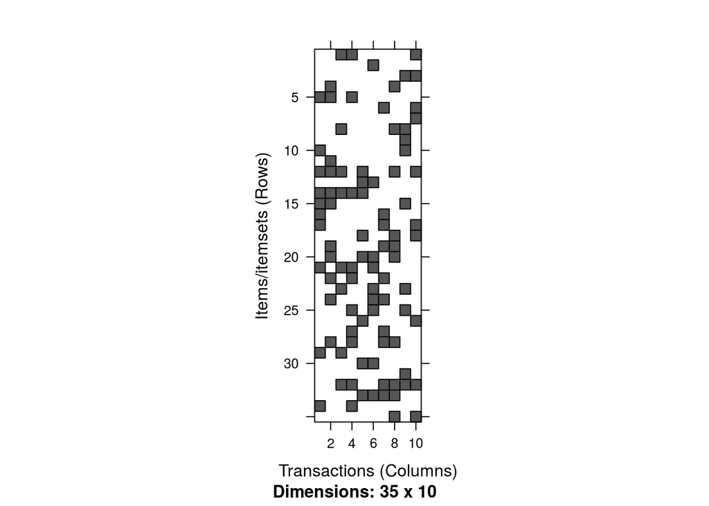

```r
image(claims_tx)
```

## Calculate and examine interesting measures

At this point, let’s see what the *aprior* algorithm has to say. First, we’ll have R calculate the relationships according to our own parameters: support, confidence and the maximum length of an association.

Support is the proportion of transactions that contain an item, confidence of the association {x, y} is the support of the union of x and y divided by the support of x.

```r
apriori(claims_tx, parameter = list(support = 0.01, confidence = 0.1, maxlen = 2))
```

```
## Apriori
##
## Parameter specification:
##  confidence minval smax arem  aval originalSupport support minlen maxlen
##         0.1    0.1    1 none FALSE            TRUE    0.01      1      2
##  target   ext
##   rules FALSE
##
## Algorithmic control:
##  filter tree heap memopt load sort verbose
##     0.1 TRUE TRUE  FALSE TRUE    2    TRUE
##
## Absolute minimum support count: 0
##
## set item appearances ...[0 item(s)] done [0.00s].
## set transactions ...[35 item(s), 10 transaction(s)] done [0.00s].
## sorting and recoding items ... [35 item(s)] done [0.00s].
## creating transaction tree ... done [0.00s].
## checking subsets of size 1 2 done [0.00s].
## writing ... [657 rule(s)] done [0.00s].
## creating S4 object  ... done [0.00s].
```

```
## set of 657 rules
```

## networking with these claims

Alright, so let’s see what data is available to visualize. I’ll just be exploring, here, so let’s start with checking out what methods are available for the `rules` class:

```r
methods(class = "rules")
```

```
##  [1] abbreviate             aggregate              coerce
##  [4] coverage               c                      dissimilarity
##  [7] duplicated             generatingItemsets     head
## [10] %in%                   info<-                 info
## [13] initialize             inspect                interestMeasure
## [16] intersect              is.element             is.maximal
## [19] is.redundant           is.significant         is.subset
## [22] is.superset            itemInfo               itemLabels
## [25] items                  labels                 length
## [28] lhs<-                  lhs                    match
## [31] plot                   quality<-              quality
## [34] rhs<-                  rhs                    [
## [37] sample                 setdiff                setequal
## [40] show                   size                   sort
## [43] subset                 summary                support
## [46] supportingTransactions tail                   t
## [49] union                  unique                 write
## see '?methods' for accessing help and source code
```